# Gene-Level Expression Comparison: Isoform-Aggregated vs Direct Quantification

NMD Study

2026-02-08

# Overview

This analysis compares gene-level expression quantifications derived from two different sources:

1. **Isoform-aggregated counts**: Transcript-level counts (long-read PacBio data) summed to gene level
2. **Direct gene-level counts**: Gene-level quantifications from independent pipeline

The comparison evaluates technical concordance between quantification methods and identifies genes with discrepant expression estimates.

## Key Considerations

- Only transcripts with Ensembl gene IDs are included in aggregation
- Datasets are matched by common Ensembl gene IDs and samples
- TMM normalization is applied separately to each matched dataset
- Comparisons are performed at multiple levels: overall, per-sample, and per-cell-type

# Load Libraries

```r
library(edgeR)
library(tidyverse)
library(knitr)
library(SummarizedExperiment)
```

# Comparison Function

Define a modular function to compare gene-level expression between isoform-aggregated and direct gene-level quantifications.

```r
compare_gene_expression <- function(dge_isoform,
                                     gene_data,
                                     gene_id_col = "ensembl_gene_id",
                                     output_prefix = "gene_expression_comparison") {

  # Prepare gene-level data ------------------------------------------------------
  # Handle DGEList, SummarizedExperiment, or counts matrix input

  if (is(gene_data, "DGEList")) {
    dge_gene <- gene_data
    cat("Gene-level input: DGEList with", nrow(dge_gene), "genes\n")
  } else if (is(gene_data, "SummarizedExperiment")) {
    # Extract counts from SummarizedExperiment
    cat("Gene-level input: SummarizedExperiment with", nrow(gene_data), "genes\n")

    # Get counts matrix
    gene_counts <- assay(gene_data, "counts")

    # Parse sample metadata from column names (format: CELLTYPE###_TREATMENT)
    sample_names <- colnames(gene_data)

    # Extract donor ID, cell type, and treatment
    parsed_metadata <- data.frame(
      sample_name = sample_names,
      stringsAsFactors = FALSE
    )

    # Parse format like "AT2001V_DMSO" -> ct="AT2", id="001V", treatment="DMSO"
    # Split by underscore
    split_names <- strsplit(sample_names, "_")
    parsed_metadata$treatment <- sapply(split_names, function(x) x[2])

    # Extract cell type and ID from first part (e.g., "AT2001V")
    # Donor ID is always 3 digits + 1 letter at the end (e.g., "001V")
    # Cell type is everything before that
    first_part <- sapply(split_names, function(x) x[1])
    parsed_metadata$id <- substr(first_part, nchar(first_part) - 3, nchar(first_part))
    parsed_metadata$ct <- substr(first_part, 1, nchar(first_part) - 4)

    cat("  Parsed sample metadata from", ncol(gene_counts), "samples\n")

    # Create DGEList
    dge_gene <- DGEList(counts = gene_counts,
                        samples = parsed_metadata)
  } else if (is.matrix(gene_data) || is.data.frame(gene_data)) {
    # Create DGEList from counts matrix using isoform sample info
    cat("Gene-level input: Counts matrix with", nrow(gene_data), "genes\n")
    cat("Creating DGEList using sample metadata from isoform data\n")
    dge_gene <- DGEList(counts = as.matrix(gene_data),
                        samples = dge_isoform$samples)
  } else {
    stop("gene_data must be a DGEList, SummarizedExperiment, or counts matrix")
  }

  # Report input dimensions
  cat("\nInput dimensions:\n")
  cat("  Isoform-level:", nrow(dge_isoform$counts), "transcripts x",
      ncol(dge_isoform$counts), "samples\n")
  cat("  Gene-level:", nrow(dge_gene$counts), "genes x",
      ncol(dge_gene$counts), "samples\n")

  # Filter and aggregate isoforms to gene level ---------------------------------
  # Only include transcripts with valid Ensembl gene IDs

  if (!gene_id_col %in% colnames(dge_isoform$genes)) {
    stop(paste("Column", gene_id_col, "not found in dge_isoform$genes"))
  }

  gene_ids <- dge_isoform$genes[[gene_id_col]]

  # Filter to transcripts with valid Ensembl gene IDs
  has_gene_id <- !is.na(gene_ids) & gene_ids != "" & gene_ids != "NA"

  # Exclude fusion transcripts (multi-gene IDs like "ENSG00000000003_ENSG00000000419")
  # These represent fusion transcripts that map to multiple genes
  is_fusion <- grepl("_ENSG", gene_ids, fixed = TRUE)

  cat("\nFiltering transcripts:\n")
  cat("  Total transcripts:", length(gene_ids), "\n")
  cat("  With valid gene IDs:", sum(has_gene_id),
      "(", round(100 * sum(has_gene_id) / length(gene_ids), 1), "%)\n")
  cat("  Fusion transcripts (excluded):", sum(is_fusion & has_gene_id),
      "(", round(100 * sum(is_fusion & has_gene_id) / sum(has_gene_id), 1), "%)\n")

  # Keep only non-fusion transcripts with valid gene IDs
  keep_transcripts <- has_gene_id & !is_fusion
  cat("  Kept for aggregation:", sum(keep_transcripts),
      "(", round(100 * sum(keep_transcripts) / length(gene_ids), 1), "%)\n")

  # Subset and aggregate
  isoform_counts_filtered <- dge_isoform$counts[keep_transcripts, ]
  gene_ids_filtered <- gene_ids[keep_transcripts]

  # Strip version numbers from gene IDs (e.g., "ENSG00000000003.16" -> "ENSG00000000003")
  gene_ids_filtered <- sub("\\.\\d+$", "", gene_ids_filtered)

  # Sum transcript counts by gene
  gene_counts_from_isoforms <- rowsum(isoform_counts_filtered,
                                      group = gene_ids_filtered)
  cat("Aggregated to", nrow(gene_counts_from_isoforms), "genes\n")

  # Match datasets by Ensembl gene ID --------------------------------------------
  # Find common genes and samples between datasets

  gene_ids_gene <- rownames(dge_gene$counts)

  # Strip version numbers from gene-level IDs (e.g., "ENSG00000000003.16" -> "ENSG00000000003")
  gene_ids_gene_clean <- sub("\\.\\d+$", "", gene_ids_gene)

  # Update rownames in gene counts
  rownames(dge_gene$counts) <- gene_ids_gene_clean

  common_genes <- intersect(rownames(gene_counts_from_isoforms), gene_ids_gene_clean)

  # Match samples by metadata (donor ID, cell type, treatment)
  # Create matching keys for both datasets

  # For isoform data
  iso_donor_id <- if ("id" %in% colnames(dge_isoform$samples)) {
    dge_isoform$samples$id
  } else if ("sample_id" %in% colnames(dge_isoform$samples)) {
    dge_isoform$samples$sample_id
  } else {
    stop("Could not find donor ID column in isoform samples")
  }

  iso_key <- paste(iso_donor_id,
                   dge_isoform$samples$ct,
                   dge_isoform$samples$treatment,
                   sep = "_")
  names(iso_key) <- colnames(gene_counts_from_isoforms)

  # For gene data
  gene_donor_id <- if ("sample_id" %in% colnames(dge_gene$samples)) {
    dge_gene$samples$sample_id
  } else if ("id" %in% colnames(dge_gene$samples)) {
    dge_gene$samples$id
  } else {
    stop("Could not find donor ID column in gene samples")
  }

  gene_key <- paste(gene_donor_id,
                    dge_gene$samples$ct,
                    dge_gene$samples$treatment,
                    sep = "_")
  names(gene_key) <- colnames(dge_gene$counts)
```

```r
  # Find common sample keys
  common_keys <- intersect(iso_key, gene_key)

  cat("\nMatching datasets:\n")
  cat("  Common genes:", length(common_genes), "\n")
  cat("  Common samples (by metadata):", length(common_keys), "\n")

  if (length(common_genes) == 0) stop("No common genes found!")
  if (length(common_keys) == 0) stop("No common samples found!")

  # Get sample names for each dataset
  iso_samples <- names(iso_key)[iso_key %in% common_keys]
  gene_samples <- names(gene_key)[gene_key %in% common_keys]

  # Reorder gene samples to match isoform sample order
  iso_keys_ordered <- iso_key[iso_samples]
  gene_samples_ordered <- gene_samples[match(iso_keys_ordered, gene_key[gene_samples])]

  # Subset both datasets to common genes and matched samples
  counts_iso_matched <- gene_counts_from_isoforms[common_genes, iso_samples]
  counts_gene_matched <- dge_gene$counts[common_genes, gene_samples_ordered]

  # Rename gene columns to match isoform column names for consistency
  colnames(counts_gene_matched) <- colnames(counts_iso_matched)

  # Create matched DGEList objects -----------------------------------------------
  # Use sample metadata from isoform DGEList

  samples_matched <- dge_isoform$samples[iso_samples, ]

  dge_iso_matched <- DGEList(counts = counts_iso_matched,
                             samples = samples_matched)
  dge_gene_matched <- DGEList(counts = counts_gene_matched,
                              samples = samples_matched)

  # TMM normalize separately -----------------------------------------------------
  # Apply TMM normalization independently to each matched dataset

  dge_iso_matched <- calcNormFactors(dge_iso_matched, method = "TMM")
  dge_gene_matched <- calcNormFactors(dge_gene_matched, method = "TMM")

  cat("\nTMM normalization factors:\n")
  cat("  Isoform range: [",
      round(min(dge_iso_matched$samples$norm.factors), 3), ", ",
      round(max(dge_iso_matched$samples$norm.factors), 3), "]\n", sep = "")
  cat("  Gene range: [",
      round(min(dge_gene_matched$samples$norm.factors), 3), ", ",
      round(max(dge_gene_matched$samples$norm.factors), 3), "]\n", sep = "")

  # Calculate CPM
  cpm_iso <- cpm(dge_iso_matched, log = FALSE)
  cpm_gene <- cpm(dge_gene_matched, log = FALSE)

  # Calculate log-transformed CPM for correlations
  log_cpm_iso <- log2(cpm_iso + 1)
  log_cpm_gene <- log2(cpm_gene + 1)

  # Overall correlations ---------------------------------------------------------
  # Correlation across all genes and samples

  # Untransformed CPM
  overall_cor_spearman <- cor(as.vector(cpm_iso), as.vector(cpm_gene),
                              method = "spearman")
  overall_cor_pearson <- cor(as.vector(cpm_iso), as.vector(cpm_gene),
                             method = "pearson")

  # Log-transformed CPM
  overall_cor_pearson_log <- cor(as.vector(log_cpm_iso), as.vector(log_cpm_gene),
                                 method = "pearson")

  # Per-sample correlations ------------------------------------------------------
  # Correlation within each sample

  sample_cors <- data.frame(
    sample = iso_samples,
    spearman = sapply(iso_samples, function(s) {
      cor(cpm_iso[, s], cpm_gene[, s], method = "spearman")
    }),
    pearson = sapply(iso_samples, function(s) {
      cor(cpm_iso[, s], cpm_gene[, s], method = "pearson")
    }),
    pearson_log = sapply(iso_samples, function(s) {
      cor(log_cpm_iso[, s], log_cpm_gene[, s], method = "pearson")
    })
  )

  # Add sample metadata (exclude 'sample' column if it exists to avoid duplicates)
  metadata_cols <- samples_matched[iso_samples, ]
  if ("sample" %in% colnames(metadata_cols)) {
    metadata_cols$sample <- NULL
  }
  sample_cors <- cbind(sample_cors, metadata_cols)

  # Per-cell-type correlations ---------------------------------------------------
  # Correlation within each cell type (if cell type info available)

  ct_cors <- NULL
  if ("ct" %in% colnames(samples_matched)) {
    cell_types <- unique(samples_matched$ct)
    ct_cors <- lapply(cell_types, function(ct) {
      ct_samples <- iso_samples[samples_matched$ct == ct]
      ct_cpm_iso <- as.vector(cpm_iso[, ct_samples])
      ct_cpm_gene <- as.vector(cpm_gene[, ct_samples])
      ct_log_cpm_iso <- as.vector(log_cpm_iso[, ct_samples])
      ct_log_cpm_gene <- as.vector(log_cpm_gene[, ct_samples])

      data.frame(
        cell_type = ct,
        n_samples = length(ct_samples),
        spearman = cor(ct_cpm_iso, ct_cpm_gene, method = "spearman"),
        pearson = cor(ct_cpm_iso, ct_cpm_gene, method = "pearson"),
        pearson_log = cor(ct_log_cpm_iso, ct_log_cpm_gene, method = "pearson")
      )
    })
    ct_cors <- do.call(rbind, ct_cors)
  }

  # Gene-level statistics --------------------------------------------------------
  # Calculate mean expression and fold differences

  mean_cpm_iso <- rowMeans(cpm_iso)
  mean_cpm_gene <- rowMeans(cpm_gene)

  # Log2 fold difference (isoform vs gene)
  fold_diff <- log2((mean_cpm_iso + 1) / (mean_cpm_gene + 1))

  # Define expressed genes (mean CPM > 1)
  expressed_genes <- (mean_cpm_iso > 1) | (mean_cpm_gene > 1)

  # Define discrepant genes (>2-fold difference and expressed)
  discrepant_genes <- abs(fold_diff) > 1 & expressed_genes

  # Create comparison data frame
  comparison_df <- data.frame(
    gene = common_genes,
    mean_cpm_isoform = mean_cpm_iso,
    mean_cpm_gene = mean_cpm_gene,
    log2_fold_diff = fold_diff,
    abs_log2_fold_diff = abs(fold_diff),
    expressed = expressed_genes,
    discrepant = discrepant_genes,
    stringsAsFactors = FALSE
  )

  # Return results ---------------------------------------------------------------

  results <- list(
    comparison_df = comparison_df,
    sample_correlations = sample_cors,
    cell_type_correlations = ct_cors,
    overall_correlations = c(spearman = overall_cor_spearman,
                            pearson = overall_cor_pearson,
                            pearson_log = overall_cor_pearson_log),
    cpm_isoform = cpm_iso,
    cpm_gene = cpm_gene,
    log_cpm_isoform = log_cpm_iso,
    log_cpm_gene = log_cpm_gene,
    dge_isoform_matched = dge_iso_matched,
    dge_gene_matched = dge_gene_matched
  )
```

```r
  # Save results -----------------------------------------------------------------

  saveRDS(results, file = paste0("../results/rds/", output_prefix, "_2026.2.7.rds"))
  write.csv(comparison_df,
            file = paste0("../results/", output_prefix, "_2026.2.7.csv"),
            row.names = FALSE)

  cat("\nResults saved to:\n")
  cat("  -", paste0("results/rds/", output_prefix, "_2026.2.7.rds\n"))
  cat("  -", paste0("results/", output_prefix, "_2026.2.7.csv\n"))

  return(results)
}
```

# Analysis 1: DGEList vs DGEList

Compare isoform-aggregated counts with direct gene-level quantifications (both in DGEList format).

## Load Data

```r
# Load isoform-level DGEList (nofilter version)
dge_isoform <- readRDS("../rds/dge_isoform_nofilter_2026.2.7.rds")

# Load gene-level DGEList (nofilter version)
dge_gene <- readRDS("../rds/dge_gene_nofilter_2026.1.3.rds")

cat("Loaded DGEList objects:\n")
```

```
## Loaded DGEList objects:
```

```r
cat("  Isoform:", nrow(dge_isoform), "transcripts x", ncol(dge_isoform), "samples\n")
```

```
##   Isoform: 1746281 transcripts x 38 samples
```

```r
cat("  Gene:", nrow(dge_gene), "genes x", ncol(dge_gene), "samples\n")
```

```
##   Gene: 63241 genes x 38 samples
```

## Identify Gene ID Column

```r
# Check available columns in isoform annotation
cat("Available columns in dge_isoform$genes:\n")
```

```
## Available columns in dge_isoform$genes:
```

```r
print(colnames(dge_isoform$genes))
```

```
## [1] "txid"                  "transcript"            "gene_id_ens115_sqanti"
## [4] "biotype"               "hgnc_symbol"           "length"
```

```r
# Determine which column contains Ensembl gene IDs
gene_id_col <- if ("ensembl_gene_id" %in% colnames(dge_isoform$genes)) {
  "ensembl_gene_id"
} else if ("gene_id" %in% colnames(dge_isoform$genes)) {
  "gene_id"
} else if ("gene_id_ens115_sqanti" %in% colnames(dge_isoform$genes)) {
  "gene_id_ens115_sqanti"
} else if ("hgnc_id" %in% colnames(dge_isoform$genes)) {
  "hgnc_id"
} else {
  stop("Could not find Ensembl gene ID column")
}

cat("\nUsing gene ID column:", gene_id_col, "\n")
```

```
##
## Using gene ID column: gene_id_ens115_sqanti
```

## Run Comparison

```r
results1 <- compare_gene_expression(
  dge_isoform = dge_isoform,
  gene_data = dge_gene,
  gene_id_col = gene_id_col,
  output_prefix = "comparison_nofilter_dgelist"
)
```

```
## Gene-level input: DGEList with 63241 genes
##
## Input dimensions:
##   Isoform-level: 1746281 transcripts x 38 samples
##   Gene-level: 63241 genes x 38 samples
##
## Filtering transcripts:
##   Total transcripts: 1746281
##   With valid gene IDs: 1746281 ( 100 %)
##   Fusion transcripts (excluded): 36188 ( 2.1 %)
##   Kept for aggregation: 1710093 ( 97.9 %)
## Aggregated to 221282 genes
##
## Matching datasets:
##   Common genes: 62188
##   Common samples (by metadata): 26
##
## TMM normalization factors:
##   Isoform range: [0.655, 1.473]
##   Gene range: [0.835, 1.158]
##
## Results saved to:
##   - results/rds/comparison_nofilter_dgelist_2026.2.7.rds
##   - results/comparison_nofilter_dgelist_2026.2.7.csv
```

# Results

## Overall Correlation

```r
cat("Overall correlation across all genes and samples:\n")
```

```
## Overall correlation across all genes and samples:
```

```r
cat("  Spearman:", round(results1$overall_correlations["spearman"], 4), "\n")
```

```
##   Spearman: 0.6212
```

```r
cat("  Pearson [log2(CPM+1)]:", round(results1$overall_correlations["pearson_log"], 4), "\n")
```

```
##   Pearson [log2(CPM+1)]: 0.6145
```

**Overall correlations:**

- **Spearman** (rank-based): 0.621
- **Pearson on log2(CPM+1)**: 0.614

The Spearman correlation of 0.621 indicates moderate rank concordance, while the log-transformed Pearson of 0.614 shows moderate linear concordance.

## Per-Sample Correlations

```r
# Summary statistics
cat("Per-sample Spearman correlation:\n")
```

```
## Per-sample Spearman correlation:
```

```r
cat("  Mean:", round(mean(results1$sample_correlations$spearman), 4), "\n")
```

```
##   Mean: 0.6224
```

```r
cat("  Range: [", round(min(results1$sample_correlations$spearman), 4), ", ",
    round(max(results1$sample_correlations$spearman), 4), "]\n", sep = "")
```

```
##   Range: [0.5895, 0.6627]
```

```r
# Display table with sample metadata
results1$sample_correlations %>%
  select(sample, ct, treatment, spearman, pearson_log) %>%
  arrange(desc(spearman)) %>%
  kable(digits = 4,
        caption = "Table 1: Per-sample correlations between isoform-aggregated and gene-level quantifications (Analysis 1)",
        col.names = c("Sample", "Cell Type", "Treatment", "Spearman", "Pearson (log)"))
```

Table 1: Per-sample correlations between isoform-aggregated and gene-level quantifications (Analysis 1)

|  | Sample | Cell Type | Treatment | Spearman | Pearson (log) |
| --- | --- | --- | --- | --- | --- |
| XCAST_20250815_R84050_PL21526-002_1-1-C01_IsoSeqX_bc07 | XCAST_20250815_R84050_PL21526-002_1-1-C01_IsoSeqX_bc07 | DD_ALI | DMSO | 0.6627 | 0.6906 |
| XCAST_20250813_R84050_PL21518-002_1-1-A01_IsoSeqX_bc01 | XCAST_20250813_R84050_PL21518-002_1-1-A01_IsoSeqX_bc01 | DD_ALI | DMSO | 0.6586 | 0.6870 |
| XCAST_20250813_R84050_PL21522-002_1-1-A01_IsoSeqX_bc04 | XCAST_20250813_R84050_PL21522-002_1-1-A01_IsoSeqX_bc04 | DD_ALI | DMSO | 0.6572 | 0.6893 |
| XCAST_20250725_R84050_PL21517-002_1-1-D01_IsoSeqX_bc12 | XCAST_20250725_R84050_PL21517-002_1-1-D01_IsoSeqX_bc12 | DD_ALI | Smg1i | 0.6522 | 0.6599 |
| XCAST_20250725_R84050_PL21521-002_1-1-D01_IsoSeqX_bc04 | XCAST_20250725_R84050_PL21521-002_1-1-D01_IsoSeqX_bc04 | DD_ALI | Smg1i | 0.6488 | 0.6652 |
| XCAST_20250725_R84050_PL21525-002_1-1-D01_IsoSeqX_bc05 | XCAST_20250725_R84050_PL21525-002_1-1-D01_IsoSeqX_bc05 | DD_ALI | Smg1i | 0.6462 | 0.6606 |
| XCAST_20250725_R84050_PL21529-002_1-1-D01_IsoSeqX_bc06 | XCAST_20250725_R84050_PL21529-002_1-1-D01_IsoSeqX_bc06 | DD | Smg1i | 0.6389 | 0.6420 |
| XCAST_20250827_R84050_PL21535-002_1-1-C01_IsoSeqX_bc03 | XCAST_20250827_R84050_PL21535-002_1-1-C01_IsoSeqX_bc03 | DD | Smg1i | 0.6380 | 0.6568 |
| XCAST_20250818_R84050_PL21531-002_1_D01_IsoSeqX_bc11_3p | XCAST_20250818_R84050_PL21531-002_1_D01_IsoSeqX_bc11_3p | DD | Smg1i | 0.6376 | 0.6504 |
| XCAST_20250827_R84050_PL21533-003_1-1-C01_IsoSeqX_bc01 | XCAST_20250827_R84050_PL21533-003_1-1-C01_IsoSeqX_bc01 | DD | Smg1i | 0.6362 | 0.6559 |
| XCAST_20250818_R84050_PL21530-002_1_D01_IsoSeqX_bc10_3p | XCAST_20250818_R84050_PL21530-002_1_D01_IsoSeqX_bc10_3p | DD | DMSO | 0.6355 | 0.6305 |
| XCAST_20250818_R84050_PL21532-002_1_D01_IsoSeqX_bc12_3p | XCAST_20250818_R84050_PL21532-002_1_D01_IsoSeqX_bc12_3p | DD | DMSO | 0.6343 | 0.6314 |
| XCAST_20250825_R84050_PL21536-002_1-1-B01_IsoSeqX_bc04 | XCAST_20250825_R84050_PL21536-002_1-1-B01_IsoSeqX_bc04 | DD | DMSO | 0.6312 | 0.6352 |
| XCAST_20250825_R84050_PL21534-003_1-1-B01_IsoSeqX_bc02 | XCAST_20250825_R84050_PL21534-003_1-1-B01_IsoSeqX_bc02 | DD | DMSO | 0.6306 | 0.6330 |
| XCAST_20251105_R8405_1_PL28441-0011-D01_IsoSeqX_bc11 | XCAST_20251105_R8405_1_PL28441-0011-D01_IsoSeqX_bc11 | FB | Smg1i | 0.6119 | 0.5888 |
| XCAST_20251105_R8405_1_PL28437-0011-C01_IsoSeqX_bc07 | XCAST_20251105_R8405_1_PL28437-0011-C01_IsoSeqX_bc07 | FB | Smg1i | 0.6050 | 0.5708 |
| XCAST_20251105_R8405_1_PL28442-0011-D01_IsoSeqX_bc12 | XCAST_20251105_R8405_1_PL28442-0011-D01_IsoSeqX_bc12 | FB | DMSO | 0.6024 | 0.5584 |
| XCAST_20251103_R84050_PL28433-001-1-B01_IsoSeqX_bc03 | XCAST_20251103_R84050_PL28433-001-1-B01_IsoSeqX_bc03 | FB | Smg1i | 0.6000 | 0.5598 |
| XCAST_20251105_R8405_1_PL28435-0011-C01_IsoSeqX_bc05 | XCAST_20251105_R8405_1_PL28435-0011-C01_IsoSeqX_bc05 | MV | Smg1i | 0.5983 | 0.5878 |
| XCAST_20251105_R8405_1_PL28438-0011-C01_IsoSeqX_bc08 | XCAST_20251105_R8405_1_PL28438-0011-C01_IsoSeqX_bc08 | FB | DMSO | 0.5967 | 0.5460 |
| XCAST_20251103_R84050_PL28431-001-1-B01_IsoSeqX_bc01 | XCAST_20251103_R84050_PL28431-001-1-B01_IsoSeqX_bc01 | MV | Smg1i | 0.5953 | 0.5786 |
| XCAST_20251105_R8405_1_PL28436-0011-C01_IsoSeqX_bc06 | XCAST_20251105_R8405_1_PL28436-0011-C01_IsoSeqX_bc06 | MV | DMSO | 0.5947 | 0.5728 |
| XCAST_20251103_R84050_PL28434-001-1-B01_IsoSeqX_bc04 | XCAST_20251103_R84050_PL28434-001-1-B01_IsoSeqX_bc04 | FB | DMSO | 0.5946 | 0.5530 |
| XCAST_20251105_R8405_1_PL28440-0011-D01_IsoSeqX_bc10 | XCAST_20251105_R8405_1_PL28440-0011-D01_IsoSeqX_bc10 | MV | DMSO | 0.5933 | 0.5720 |
| XCAST_20251105_R8405_1_PL28439-0011-D01_IsoSeqX_bc09 | XCAST_20251105_R8405_1_PL28439-0011-D01_IsoSeqX_bc09 | MV | Smg1i | 0.5927 | 0.5696 |
| XCAST_20251103_R84050_PL28432-001-1-B01_IsoSeqX_bc02 | XCAST_20251103_R84050_PL28432-001-1-B01_IsoSeqX_bc02 | MV | DMSO | 0.5895 | 0.5595 |

Per-sample correlations range from **0.59** to **0.663**, with a mean of **0.622**.

## Gene-Level Summary

```r
comp_df <- results1$comparison_df

cat("Gene-level statistics:\n")
```

```
## Gene-level statistics:
```

```r
cat("  Total common genes:", nrow(comp_df), "\n")
```

```
##   Total common genes: 62188
```

```r
cat("  Expressed genes (mean CPM > 1):", sum(comp_df$expressed), "\n")
```

```
##   Expressed genes (mean CPM > 1): 20535
```

```r
cat("  Discrepant genes (>2-fold diff, expressed):", sum(comp_df$discrepant), "\n")
```

```
##   Discrepant genes (>2-fold diff, expressed): 15945
```

```r
cat("\nSummary statistics for expressed genes:\n")
```

```
##
## Summary statistics for expressed genes:
```

```r
cat("  Median absolute CPM difference:",
    round(median(abs(comp_df$mean_cpm_isoform - comp_df$mean_cpm_gene)[comp_df$expressed]), 2), "\n")
```

```
##   Median absolute CPM difference: 14.48
```

```r
cat("  Mean absolute CPM difference:",
    round(mean(abs(comp_df$mean_cpm_isoform - comp_df$mean_cpm_gene)[comp_df$expressed]), 2), "\n")
```

```
##   Mean absolute CPM difference: 70.67
```

```r
cat("  Median |log2 fold difference|:",
    round(median(comp_df$abs_log2_fold_diff[comp_df$expressed]), 3), "\n")
```

```
##   Median |log2 fold difference|: 1.921
```

Of **62,188** common genes, **20,535** are expressed (mean CPM > 1) and **15945** show discrepant quantifications (>2-fold difference).

## Top Discrepant Genes

```r
comp_df %>%
  filter(expressed) %>%
  arrange(desc(abs_log2_fold_diff)) %>%
  head(20) %>%
  select(gene, log2_fold_diff, mean_cpm_isoform, mean_cpm_gene) %>%
  kable(digits = 3,
        caption = "Table 2: Top 20 genes with largest expression differences (Analysis 1)",
        col.names = c("Gene", "log2(Isoform/Gene)", "Mean CPM (Isoform)", "Mean CPM (Gene)"))
```

Table 2: Top 20 genes with largest expression differences (Analysis 1)

|  | Gene | log2(Isoform/Gene) | Mean CPM (Isoform) | Mean CPM (Gene) |
| --- | --- | --- | --- | --- |
| ENSG00000273976 | ENSG00000273976 | 13.397 | 10850.696 | 0.006 |
| ENSG00000186487 | ENSG00000186487 | 13.280 | 10189.520 | 0.024 |
| ENSG00000198804 | ENSG00000198804 | -12.987 | 0.167 | 9471.755 |
| ENSG00000225794 | ENSG00000225794 | 11.805 | 3754.925 | 0.049 |
| ENSG00000203546 | ENSG00000203546 | 11.780 | 7923.801 | 1.254 |
| ENSG00000168124 | ENSG00000168124 | 11.594 | 3448.335 | 0.116 |
| ENSG00000198938 | ENSG00000198938 | -11.593 | 0.026 | 3167.097 |
| ENSG00000290875 | ENSG00000290875 | 11.587 | 3229.272 | 0.050 |
| ENSG00000249818 | ENSG00000249818 | 11.465 | 2826.814 | 0.000 |
| ENSG00000232084 | ENSG00000232084 | 11.387 | 2681.617 | 0.001 |
| ENSG00000286044 | ENSG00000286044 | 11.343 | 3275.930 | 0.262 |
| ENSG00000134962 | ENSG00000134962 | 11.271 | 3140.697 | 0.271 |
| ENSG00000234446 | ENSG00000234446 | 11.267 | 2462.917 | 0.000 |
| ENSG00000198712 | ENSG00000198712 | -11.219 | 0.062 | 2530.272 |
| ENSG00000280809 | ENSG00000280809 | 11.195 | 2352.278 | 0.004 |
| ENSG00000230317 | ENSG00000230317 | 11.189 | 2347.919 | 0.006 |
| ENSG00000156508 | ENSG00000156508 | -11.059 | 4.282 | 11266.659 |
| ENSG00000204136 | ENSG00000204136 | 11.047 | 2955.924 | 0.397 |
| ENSG00000290559 | ENSG00000290559 | 11.041 | 2125.657 | 0.009 |
| ENSG00000168878 | ENSG00000168878 | 10.993 | 2128.451 | 0.045 |

These genes show the largest discrepancies between quantification methods. Positive log2 fold differences indicate higher expression in isoform-aggregated data; negative values indicate higher expression in direct gene-level data.

## Gene Length Effects

```r
# Identify dominant isoform for each gene
# Use mean expression across all samples to determine dominant isoform

# Get isoform-level expression data
iso_cpm <- cpm(dge_isoform, log = FALSE)

# Filter to isoforms with valid gene IDs and not fusion transcripts
gene_ids <- dge_isoform$genes$gene_id_ens115_sqanti
has_gene_id <- !is.na(gene_ids) & gene_ids != "" & gene_ids != "NA"
is_fusion <- grepl("_ENSG", gene_ids, fixed = TRUE)
keep_tx <- has_gene_id & !is_fusion

# Strip version numbers and get filtered data
gene_ids_clean <- sub("\\.\\d+$", "", gene_ids[keep_tx])
iso_cpm_filtered <- iso_cpm[keep_tx, ]
iso_lengths <- dge_isoform$genes$length[keep_tx]

# Calculate mean expression per isoform across samples
mean_iso_expr <- rowMeans(iso_cpm_filtered)

# Create data frame with isoform info
iso_df <- data.frame(
  txid = rownames(iso_cpm_filtered),
  gene_id = gene_ids_clean,
  length = iso_lengths,
  mean_expr = mean_iso_expr,
  stringsAsFactors = FALSE
)

# Remove isoforms without length information
iso_df <- iso_df[!is.na(iso_df$length), ]

# Identify dominant isoform per gene (highest mean expression)
dominant_isoforms <- iso_df %>%
  group_by(gene_id) %>%
  arrange(desc(mean_expr)) %>%
  dplyr::slice(1) %>%
  ungroup() %>%
  select(gene_id, dominant_length = length, dominant_expr = mean_expr)

cat("Identified dominant isoforms for", nrow(dominant_isoforms), "genes\n")
```

```
## Identified dominant isoforms for 154920 genes
```

```r
cat("Gene length range:", min(dominant_isoforms$dominant_length), "-",
    max(dominant_isoforms$dominant_length), "bp\n")
```

```
## Gene length range: 112 - 8551 bp
```

```r
cat("Median gene length:", median(dominant_isoforms$dominant_length), "bp\n")
```

```
## Median gene length: 1767 bp
```

```r
# Merge with comparison data
comp_df_length <- comp_df %>%
  left_join(dominant_isoforms, by = c("gene" = "gene_id")) %>%
  filter(!is.na(dominant_length), expressed)

cat("\nGenes with length info and expressed:", nrow(comp_df_length), "\n")
```

```
##
## Genes with length info and expressed: 15891
```

```r
# Analyze relationship between length and discrepancy
cor_length_discrepancy <- cor(comp_df_length$dominant_length,
                               comp_df_length$abs_log2_fold_diff,
                               method = "spearman")
cat("Spearman correlation between gene length and absolute fold difference:",
    round(cor_length_discrepancy, 4), "\n")
```

```
## Spearman correlation between gene length and absolute fold difference: -0.0736
```

```r
# Bin genes by length quartiles
comp_df_length <- comp_df_length %>%
  mutate(length_bin = cut(dominant_length,
                          breaks = quantile(dominant_length, probs = c(0, 0.25, 0.5, 0.75, 1)),
                          labels = c("Q1 (shortest)", "Q2", "Q3", "Q4 (longest)"),
                          include.lowest = TRUE))

# Calculate statistics by length bin
length_stats <- comp_df_length %>%
  group_by(length_bin) %>%
  summarise(
    n_genes = n(),
    median_length = median(dominant_length),
    median_abs_fold_diff = median(abs_log2_fold_diff),
    pct_discrepant = 100 * sum(discrepant) / n(),
    .groups = "drop"
  )

cat("\n")
```

```r
print(kable(length_stats, digits = 2,
            caption = "Table 4: Gene length effects on quantification concordance",
            col.names = c("Length Quartile", "N Genes", "Median Length (bp)",
                         "Median |log2FC|", "% Discrepant")))
```

```
##
##
## Table: Table 4: Gene length effects on quantification concordance
##
## |Length Quartile | N Genes| Median Length (bp)| Median &#124;log2FC&#124;| % Discrepant|
## |:---------------|-------:|------------------:|-------------------------:|------------:|
## |Q1 (shortest)   |    3974|               1457|                      1.93|        75.19|
## |Q2              |    3978|               2512|                      1.94|        74.79|
## |Q3              |    3969|               3104|                      1.76|        72.06|
## |Q4 (longest)    |    3970|               3941|                      1.67|        69.65|
```

**Gene length analysis:**

Dominant isoform lengths were identified for **15891** expressed genes. The Spearman correlation between gene length and absolute fold difference is **-0.074**, suggesting minimal relationship between gene length and quantification discrepancy.

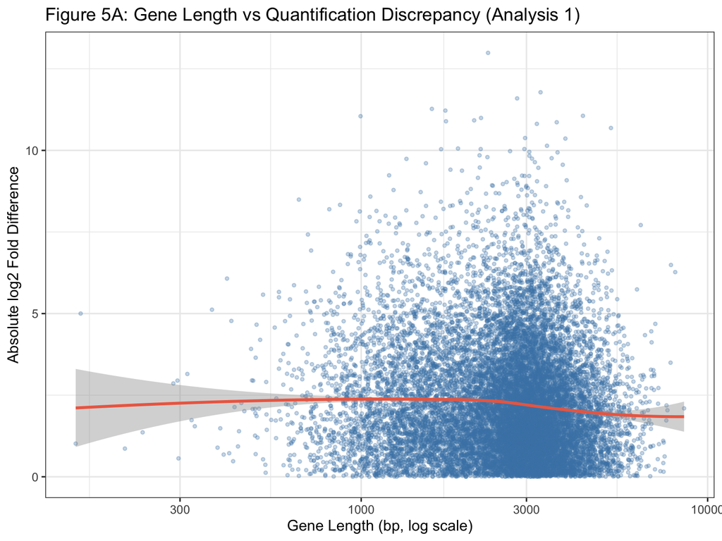

```r
# Scatter plot: gene length vs discrepancy
ggplot(comp_df_length, aes(x = dominant_length, y = abs_log2_fold_diff)) +
  geom_point(alpha = 0.3, size = 1, color = "steelblue") +
  geom_smooth(method = "loess", color = "coral2", se = TRUE) +
  scale_x_log10() +
  labs(x = "Gene Length (bp, log scale)",
       y = "Absolute log2 Fold Difference",
       title = "Figure 5A: Gene Length vs Quantification Discrepancy (Analysis 1)") +
  theme_bw(base_size = 12)
```

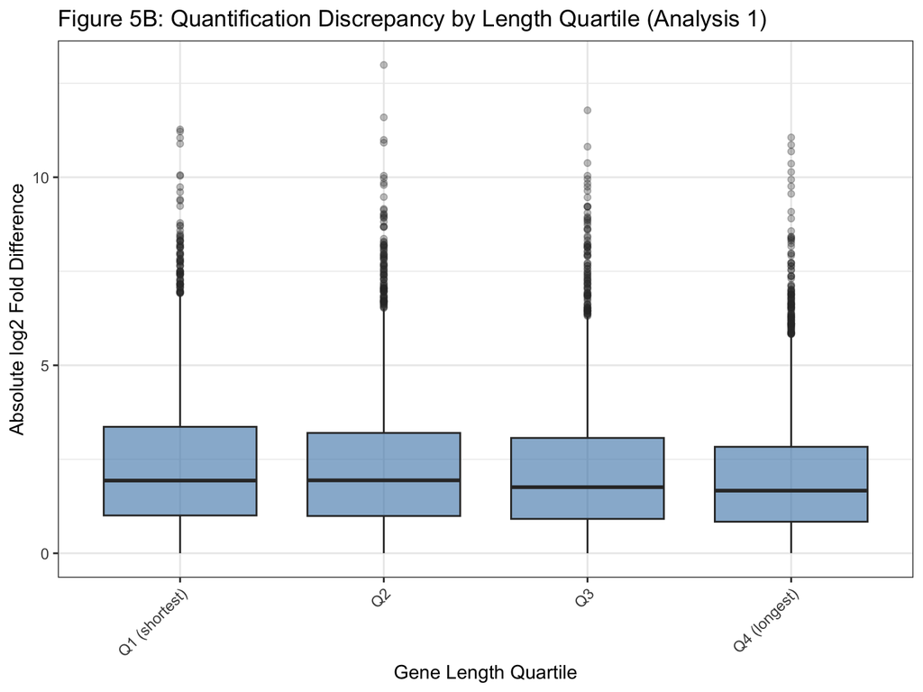

```r
# Boxplot: discrepancy by length quartile
ggplot(comp_df_length, aes(x = length_bin, y = abs_log2_fold_diff)) +
  geom_boxplot(fill = "steelblue", alpha = 0.6, outlier.alpha = 0.3) +
  labs(x = "Gene Length Quartile",
       y = "Absolute log2 Fold Difference",
       title = "Figure 5B: Quantification Discrepancy by Length Quartile (Analysis 1)") +
  theme_bw(base_size = 12) +
  theme(axis.text.x = element_text(angle = 45, hjust = 1))
```

The analysis shows minimal systematic effect of gene length on quantification concordance.

# Scatter Plot: Mean Expression

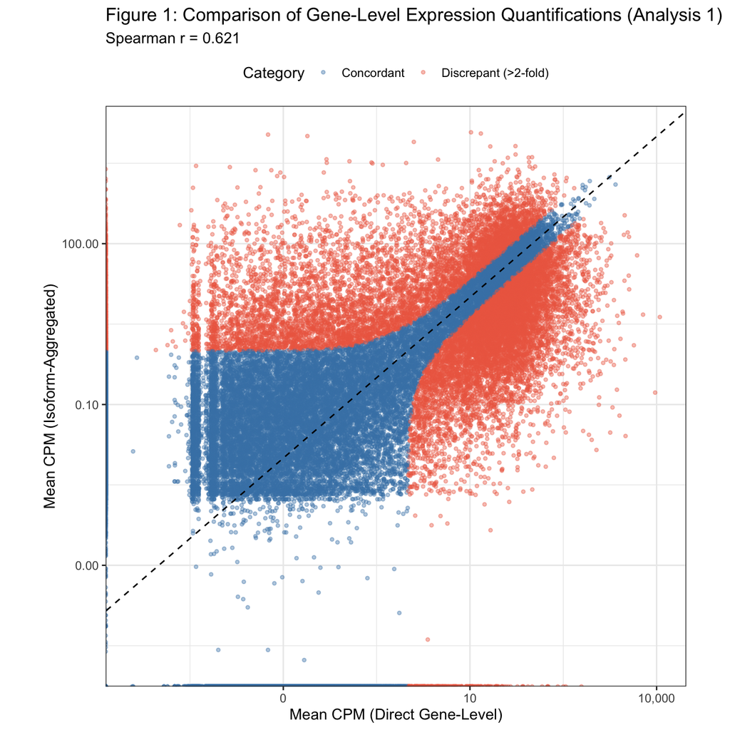

```r
# Prepare data for plotting
plot_df <- comp_df %>%
  mutate(category = case_when(
    discrepant ~ "Discrepant (>2-fold)",
    TRUE ~ "Concordant"
  ))

# Create scatter plot
ggplot(plot_df, aes(x = mean_cpm_gene, y = mean_cpm_isoform, color = category)) +
  geom_point(alpha = 0.4, size = 1) +
  geom_abline(slope = 1, intercept = 0, linetype = "dashed", color = "black") +
  scale_x_log10(labels = scales::comma) +
  scale_y_log10(labels = scales::comma) +
  scale_color_manual(values = c("Concordant" = "steelblue",
                                 "Discrepant (>2-fold)" = "coral2")) +
  labs(x = "Mean CPM (Direct Gene-Level)",
       y = "Mean CPM (Isoform-Aggregated)",
       title = "Figure 1: Comparison of Gene-Level Expression Quantifications (Analysis 1)",
       subtitle = paste0("Spearman r = ", round(results1$overall_correlations["spearman"], 3)),
       color = "Category") +
  theme_bw(base_size = 12) +
  theme(legend.position = "top",
        aspect.ratio = 1)
```

The scatter plot shows overall concordance between quantification methods on the original CPM scale. Discrepant genes (coral points) deviate from the diagonal unity line.

## Scatter Plot: Log2-Transformed Expression

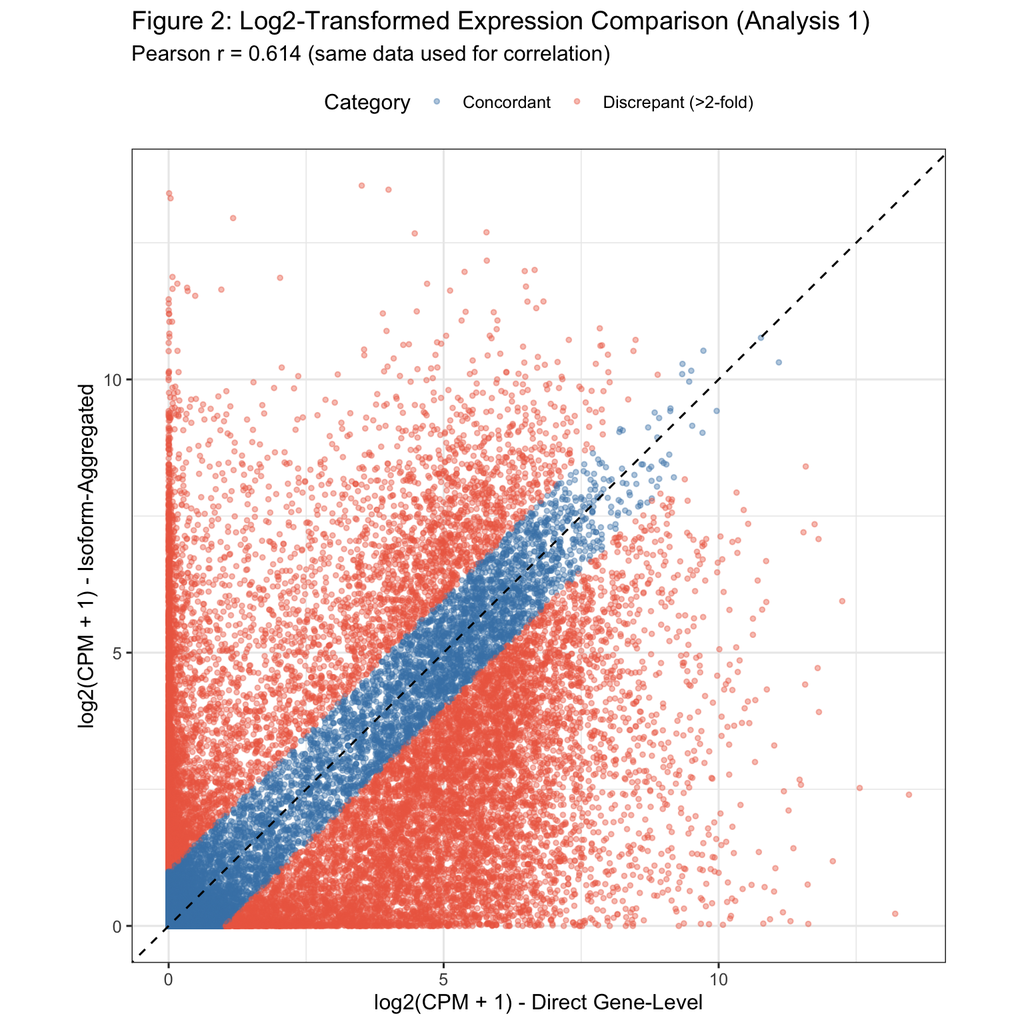

```r
# Prepare data with log2-transformed values
# These are the same values used for Pearson correlation calculation
plot_df_log2 <- comp_df %>%
  mutate(
    log2_cpm_gene = log2(mean_cpm_gene + 1),
    log2_cpm_isoform = log2(mean_cpm_isoform + 1),
    category = case_when(
      discrepant ~ "Discrepant (>2-fold)",
      TRUE ~ "Concordant"
    )
  )

# Create scatter plot with log2-transformed data
ggplot(plot_df_log2, aes(x = log2_cpm_gene, y = log2_cpm_isoform, color = category)) +
  geom_point(alpha = 0.4, size = 1) +
  geom_abline(slope = 1, intercept = 0, linetype = "dashed", color = "black") +
  scale_color_manual(values = c("Concordant" = "steelblue",
                                 "Discrepant (>2-fold)" = "coral2")) +
  labs(x = "log2(CPM + 1) - Direct Gene-Level",
       y = "log2(CPM + 1) - Isoform-Aggregated",
       title = "Figure 2: Log2-Transformed Expression Comparison (Analysis 1)",
       subtitle = paste0("Pearson r = ", round(results1$overall_correlations["pearson_log"], 3),
                        " (same data used for correlation)"),
       color = "Category") +
  theme_bw(base_size = 12) +
  theme(legend.position = "top",
        aspect.ratio = 1)
```

This plot shows the same comparison using log2-transformed CPM values, which is the data used for calculating the Pearson correlation (r = 0.614). The linear scale reveals the correlation structure more clearly than the log-log plot.